# An Idealized World

Where Every Relationship Is Perfectly Mirrored

# The Mirror Matrix

Suppose we refuse asymmetry. We insist that every edge runs both ways, or, more strongly, that the whole pattern is unchanged when we reflect it.

We call such an object a **mirror matrix**. Geometrically it is the adjacency matrix of an undirected graph, or the incidence structure of a figure that possesses reflection symmetry.

## Forcing the mirror

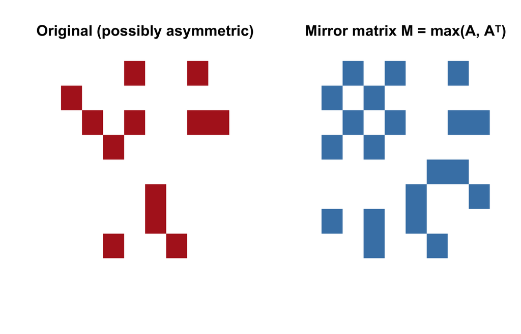

An arbitrary directed graph symmetrized into a mirror matrix

```r
g_dir <- sample_gnm(8, 12, directed = TRUE)
A_dir <- as_adjacency_matrix(g_dir, sparse = FALSE)
# mirror: average with transpose (or logical OR)
M <- pmax(A_dir, t(A_dir)) # 1 if either direction exists

par(mfrow = c(1, 2))
image(t(A_dir[nrow(A_dir):1, ]),
  axes = FALSE, col = c("white", "firebrick"),
  main = "Original (possibly asymmetric)"
)
image(t(M[nrow(M):1, ]),
  axes = FALSE, col = c("white", "steelblue"),
  main = "Mirror matrix M = max(A, Aᵀ)"
)
```

## Geometric mirror symmetry

The same ideal appears in the plane: a shape that is identical to its reflection.

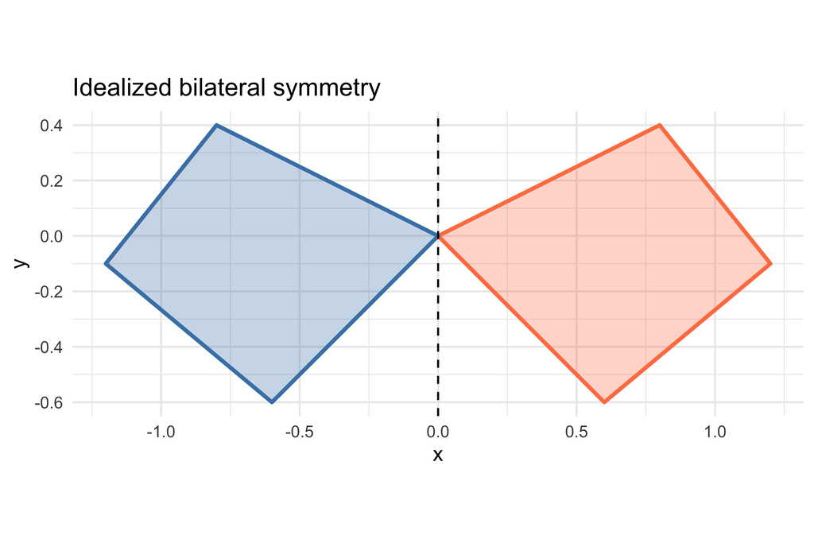

A motif and its perfect mirror

```r
motif <- data.frame(
  x = c(0, 0.8, 1.2, 0.6, 0),
  y = c(0, 0.4, -0.1, -0.6, 0)
)
mirror <- data.frame(x = -motif$x, y = motif$y)

ggplot() +
  geom_polygon(
    data = motif, aes(x, y), fill = "coral", alpha = 0.3,
    color = "coral", linewidth = 1
  ) +
  geom_polygon(
    data = mirror, aes(x, y), fill = "steelblue", alpha = 0.3,
    color = "steelblue", linewidth = 1
  ) +
  geom_vline(xintercept = 0, linetype = "dashed") +
  coord_fixed() +
  theme_minimal() +
  labs(title = "Idealized bilateral symmetry")
```

## Dihedral ideal

Full dihedral symmetry ( D_n ) is the strongest mirror ideal: the figure is unchanged by any of the ( n ) rotations *and* any of the ( n ) reflections of a regular ( n )-gon.

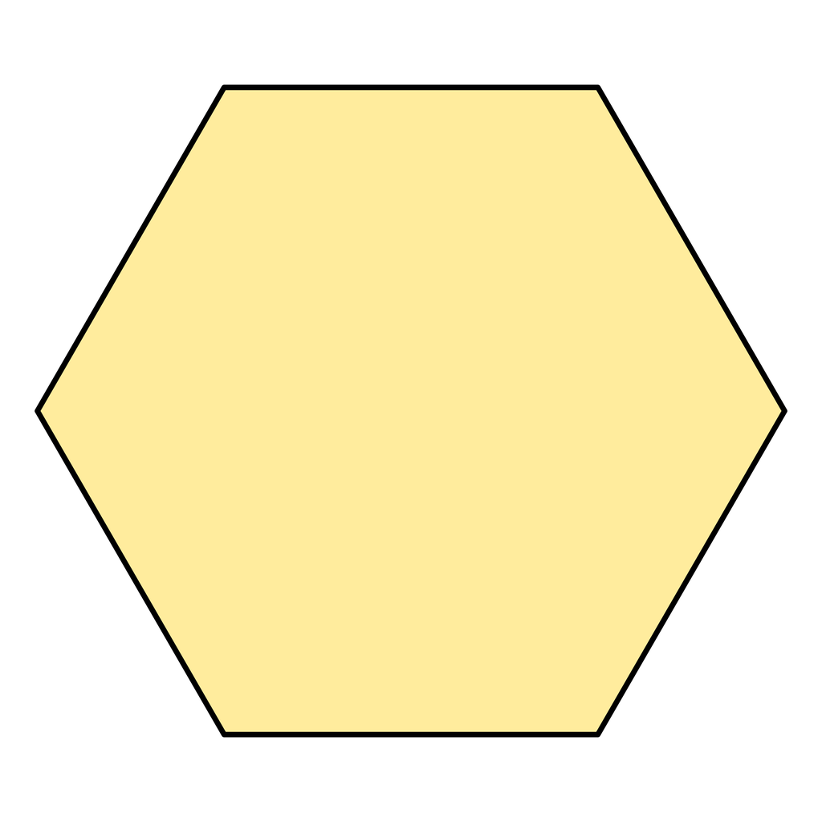

Regular hexagon — the D6 mirror ideal

```r
n <- 6
ang <- seq(0, 2 * pi, length.out = n + 1)
poly <- data.frame(x = cos(ang), y = sin(ang))
ggplot(poly, aes(x, y)) +
  geom_polygon(fill = "gold", alpha = 0.4, color = "black", linewidth = 1) +
  coord_fixed() +
  theme_void()
```

# The Idealized Claim

In this world:

- every friendship is mutual,
- every influence is reciprocal,
- every geometric motif possesses exact reflection or dihedral symmetry,
- the adjacency (or transformation) matrix is identical to its mirror.

It is clean, balanced, and often beautiful — but it is an idealization.  
The next document asks what survives when the real world refuses to be perfectly mirrored.